# Hypothesis Testing - Tooth Growth Sample Data

Kate Prendergast

### Overview

In this report, we will examine a fairly small dataset that shows tooth growth results from Vitamin C, using one of two delivery methods and given at three different doses. We will examine whether the data appears to be normally distributed, and if so, determine if the differences in resutls appear to be statistically significant.

### Data Summary

We first load the ToothGrowth dataset and use the stat.desc() function to perform some initial analysis of the data.

```r
library(datasets)
library(pastecs)
data("ToothGrowth")
stat.desc(ToothGrowth, norm = TRUE)
```

```
##                       len supp          dose
## nbr.val        60.0000000   NA  6.000000e+01
## nbr.null        0.0000000   NA  0.000000e+00
## nbr.na          0.0000000   NA  0.000000e+00
## min             4.2000000   NA  5.000000e-01
## max            33.9000000   NA  2.000000e+00
## range          29.7000000   NA  1.500000e+00
## sum          1128.8000000   NA  7.000000e+01
## median         19.2500000   NA  1.000000e+00
## mean           18.8133333   NA  1.166667e+00
## SE.mean         0.9875223   NA  8.118705e-02
## CI.mean.0.95    1.9760276   NA  1.624549e-01
## var            58.5120226   NA  3.954802e-01
## std.dev         7.6493152   NA  6.288722e-01
## coef.var        0.4065901   NA  5.390333e-01
## skewness       -0.1425376   NA  3.722966e-01
## skew.2SE       -0.2308721   NA  6.030190e-01
## kurtosis       -1.0425144   NA -1.549583e+00
## kurt.2SE       -0.8566377   NA -1.273298e+00
## normtest.W      0.9674286   NA  7.649050e-01
## normtest.p      0.1091005   NA  1.990132e-08
```

Based on the Shapiro-Wilk normality test statistic p-value of 0.11 calculated for this dataset and an assumed significance level of 0.05, we will not reject the hypothesis that the data is normally distributed and can proceed with confidence estimates using a t-distribution.

### Testing

We start by plotting the results by dose and delivery method. Dose values are 0.5, 1, and 2. Delivery methods are OJ and VC, which stand for Orange Juice and Ascorbic Acid, respectively.

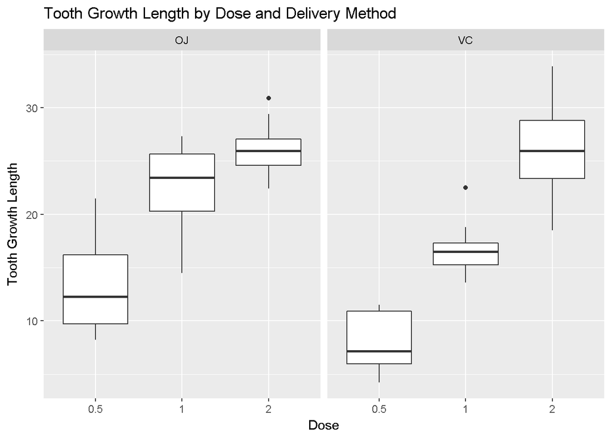

```r
library(ggplot2)
qplot(factor(dose), len, data = ToothGrowth, geom = "boxplot", facets = .~supp,
      xlab = "Dose", ylab = "Tooth Growth Length",
      main = "Tooth Growth Length by Dose and Delivery Method")
```

There doesn’t appear to be significant differences by delivery method, but the dose does seem to affect the length of tooth growth. Let’s further examine this usingt-test confidence intervals.

After subsetting the data by dose so that we can compare two at a time, we then compare the 0.5 to 1.0 doses, 1.0 to 2.0, and 0.5 to 2.0 We look at the confidence interval for each comparison, which will show with 95% confidence what the difference in the mean is between the two data sets involved.

```r
## subset the data by dose
dose05 <- subset(ToothGrowth, dose == 0.5)
dose1 <- subset(ToothGrowth, dose == 1.0)
dose2 <- subset(ToothGrowth, dose == 2.0)
## perform test for each combination, binding resutls together for formatting ease
rbind(as.numeric(t.test(dose05$len, dose1$len)$conf.int),
as.numeric(t.test(dose1$len, dose2$len)$conf.int),
as.numeric(t.test(dose05$len, dose2$len)$conf.int))
```

```
##            [,1]       [,2]
## [1,] -11.983781  -6.276219
## [2,]  -8.996481  -3.733519
## [3,] -18.156167 -12.833833
```

In all 3 cases, since 0 is not in the interval, we can say with 95% confidence that the difference in the means is significant (non-zero) and that dose does affect the tooth growth results.

Now we repeat this analysis comparing the two methods of delivery.

```r
## subset the data by delivery method
oj <- subset(ToothGrowth, supp == "OJ")
vc <- subset(ToothGrowth, supp == "VC")
## perform test comparing the two methods
as.numeric(t.test(oj$len, vc$len)$conf.int)
```

```
## [1] -0.1710156  7.5710156
```

As suspected, the confidence interval does contain 0, so we cannot rule out the possibility that there is no difference in the means of the data for the two delivery methods.

### Summary

Based on our t-test confidence interval testing, there does seem to be a significant difference in results based on the dose but not based on the delivery method.